# Will use my 2 late days for this problem set

```python
import csv
import numpy as np
import pandas as pd
import matplotlib.pyplot as plt


from sklearn.linear_model import LinearRegression
from sklearn.decomposition import PCA

from sklearn.feature_extraction.text import CountVectorizer, TfidfTransformer
from sklearn.naive_bayes import MultinomialNB
from sklearn.svm import SVC, LinearSVC
from sklearn.metrics import classification_report, f1_score, accuracy_score, confusion_matrix
from sklearn.pipeline import Pipeline
from sklearn.model_selection import GridSearchCV
from sklearn.model_selection import StratifiedKFold, cross_val_score, train_test_split
from sklearn.tree import DecisionTreeClassifier
from sklearn.model_selection import learning_curve
from sklearn.neighbors import KNeighborsClassifier
from sklearn.model_selection import KFold, cross_validate # for Cross-validation
from sklearn.tree import DecisionTreeClassifier
from sklearn import tree, ensemble



from sklearn import datasets, linear_model
from sklearn.metrics import mean_squared_error, r2_score
from sklearn.preprocessing import StandardScaler
from sklearn.model_selection import train_test_split
from sklearn.linear_model import SGDRegressor
from sklearn.pipeline import make_pipeline
from sklearn.cluster import KMeans

#evaluate accurayc scores to see players performance
```

# 1. Principal Component Analysis

```python
df_data = pd.read_csv('./housing_data.csv')
all_features = ['crim', 'zn', 'indus', 'chas', 'nox', 'rm', 'age', 'dis', 'rad', 'tax', 'ptratio', 'b', 'lstat']
X = df_data[all_features]
y = df_data["medv"]
```

## 1.1 Scatterplot

#### 1.1A

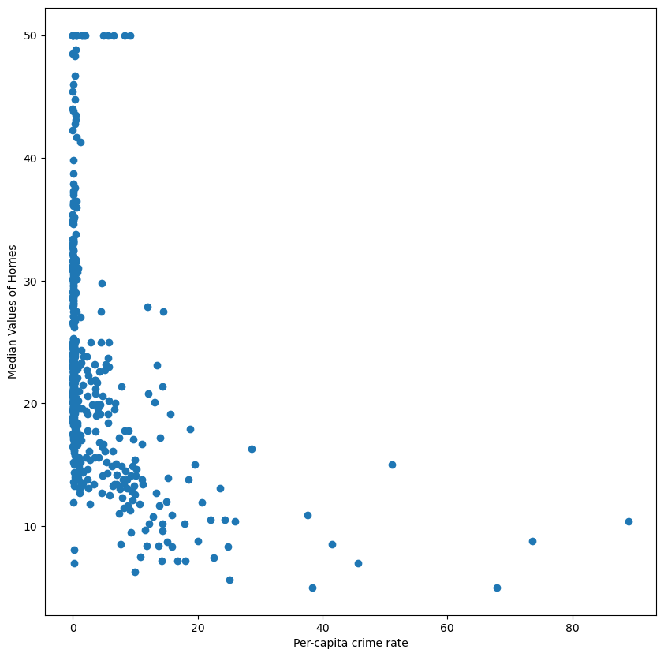

```python
# Scatterplot diagram
plt.figure(figsize = (10,10))

xCrim = X['crim']

plt.scatter(xCrim, y)

plt.ylabel('Median Values of Homes')
plt.xlabel('Per-capita crime rate')
plt.show()
```

#### 1.1B

```python
xCrimReshape = xCrim.values.reshape(-1,1)
```

```python
X_train, X_test, Y_train, Y_test = train_test_split(xCrimReshape, y , test_size = 0.34, random_state = 42)
```

```python
linearModel = LinearRegression()


linearModel.fit(X_train, Y_train)

yTrainingPred = linearModel.predict(X_train)
yTestingPred = linearModel.predict(X_test)

mseTraining = mean_squared_error(Y_train, yTrainingPred)
mseTest = mean_squared_error(Y_test, yTestingPred)



rmseTrainingSet = np.sqrt(mseTraining)

rmseTestSet = np.sqrt(mseTest)

print(f"Training Set RMSE: {rmseTrainingSet}")

print(f"Test Set RMSE: {rmseTestSet}")
```

```
Training Set RMSE: 8.75564310331614
Test Set RMSE: 7.936257817341228
```

## 1.2 Features and plots

```python
picked_features = ['crim', 'zn', 'indus', 'chas', 'nox', 'rm', 'age', 'dis']
selectedData = df_data[picked_features]
```

```python
X_train, X_test, Y_train, Y_test = train_test_split(X, y , test_size = 0.34, random_state = 42)
```

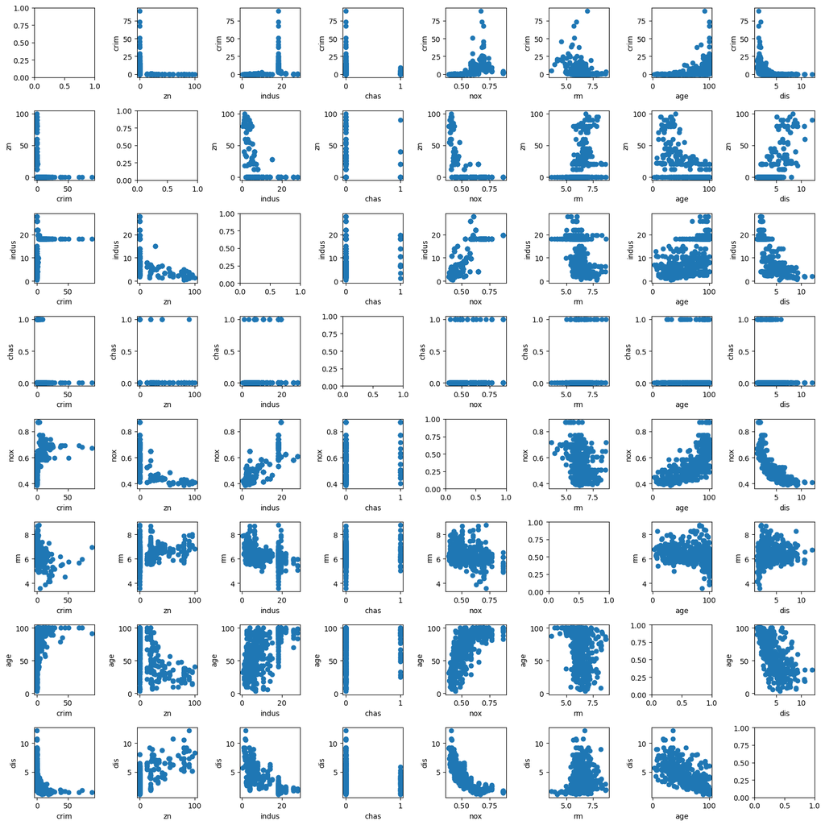

```python
plt.figure(figsize=(16,16))
for i, iFeatures in enumerate(picked_features):
    for j, jFeatures in enumerate(picked_features):
        plt.subplot(8, 8, i * 8 + j + 1)
        if i != j:
            plt.scatter(selectedData[jFeatures], selectedData[iFeatures])
            plt.ylabel(iFeatures)
            plt.xlabel(jFeatures)


plt.tight_layout()
```

## 1.3 PCA to the Rescue

```python
X_train, X_test, Y_train, Y_test  = train_test_split(X, y , test_size = 0.34, random_state = 42)
```

```python
pcaComp = PCA(n_components = 12)
```

```python
pcaComp.fit(X_train)
```

```
PCA(n_components=12)
```

```python
explainedVariance= pcaComp.explained_variance_
```

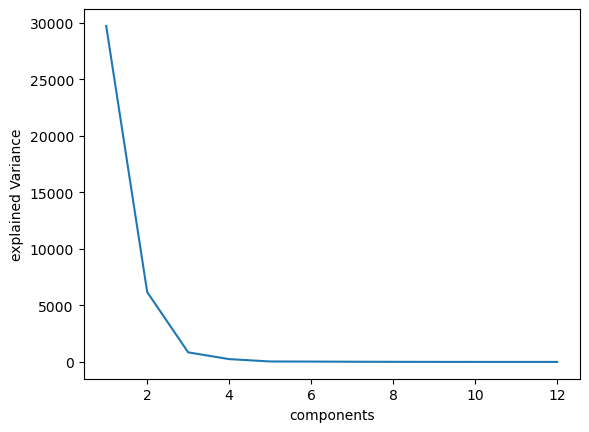

```python
plt.plot(range(1,13), explainedVariance)
plt.ylabel('explained Variance')
plt.xlabel('components')
```

## 1.4 Visualizing the components

```python
X_train, X_test, Y_train, Y_test  = train_test_split(X, y , test_size = 0.34, random_state = 42)
pca = PCA(n_components = 2)
```

```python
pca.fit(X_train)
```

```
PCA(n_components=2)
```

```python
pcaTransform = pca.transform(X_train)
```

```python
#plt.figure(figsize=(15,5))
```

```python
#1.4.1
```

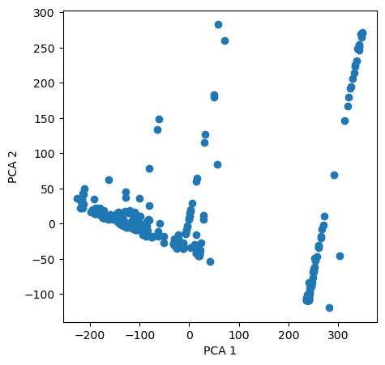

```python
plt.figure(figsize = (5,5))
plt.scatter(pcaTransform[:, 0], pcaTransform[:, 1])
plt.xlabel('PCA 1')
plt.ylabel('PCA 2')
```

```python
#1.4.2
```

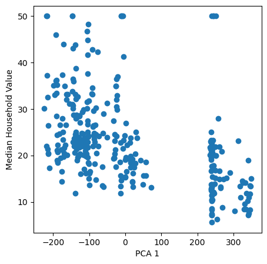

```python
#Call the comp
pca1Comp = PCA(n_components = 1)

#Fit it
pca1Comp.fit(X_train)

#transform
pca1CompTransform = pca1Comp.transform(X_train)

plt.figure(figsize = (5,5))
plt.scatter(pca1CompTransform, Y_train)
plt.xlabel('PCA 1')
plt.ylabel('Median Household Value')
```

```python
#1.4.3
```

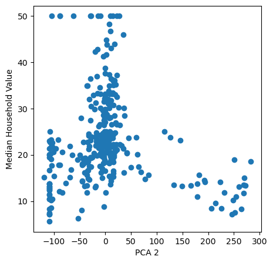

```python
pcaTransform = pca.transform(X_train)

plt.figure(figsize = (5,5))
plt.scatter(pcaTransform[:, 1], Y_train)
plt.xlabel('PCA 2')
plt.ylabel('Median Household Value')
```

## 1.5 Regression and PCA

```python
X_train, X_test, Y_train, Y_test  = train_test_split(X, y , test_size = 0.34, random_state = 42)
pca = PCA(n_components = 1)
```

```python
XpcaTraining = pca.fit_transform(X_train)
XpcaTesting = pca.transform(X_test)
```

```python
linearRegressionModel = LinearRegression()
linearRegressionModel.fit(XpcaTraining, Y_train)
```

```
LinearRegression()
```

```python
yTrainingPrediction = linearRegressionModel.predict(XpcaTraining)
yTestingPrediction = linearRegressionModel.predict(XpcaTesting)
```

```python
trainingMSE = mean_squared_error(Y_train, yTrainingPrediction)
testingMSE = mean_squared_error(Y_test ,yTestingPrediction)
```

```python
trainingRMSE = np.sqrt(trainingMSE)
testingRMSE = np.sqrt(testingMSE)
```

```python
print(f"Training Set RMSE: {trainingRMSE}")
```

```
Training Set RMSE: 8.33237315067363
```

```python
print(f"Test Set RMSE: {testingRMSE}")
```

```
Test Set RMSE: 7.455885079509068
```

## Result / Interpretation

- Answers between test set and training set from 1.1 and 1.5 are very similar in value
- Since the values are really similar this proposes the reduced dimensional model performs at the same level as the other model(even though this model has all of its features)
- Overall, this would mean that the one singular principal component retained essential data causing comparable values between the models